# Taller ANOVA - Kruskal Wallis

Departamento de Estadística - Universidad Nacional

# Librerías

```r
library(ggplot2)
library(dplyr)
library(nortest)
library(car)
library(gridExtra)
library(PMCMRplus)
library(dunn.test)
```

# Cargar datos

```r
data("PlantGrowth")
dat<-PlantGrowth
head(dat)
```

```
##   weight group
## 1   4.17  ctrl
## 2   5.58  ctrl
## 3   5.18  ctrl
## 4   6.11  ctrl
## 5   4.50  ctrl
## 6   4.61  ctrl
```

## Visualización datos

```r
head(dat)
```

```
##   weight group
## 1   4.17  ctrl
## 2   5.58  ctrl
## 3   5.18  ctrl
## 4   6.11  ctrl
## 5   4.50  ctrl
## 6   4.61  ctrl
```

## Estructura base de datos

```r
str(dat)
```

```
## 'data.frame':    30 obs. of  2 variables:
##  $ weight: num  4.17 5.58 5.18 6.11 4.5 4.61 5.17 4.53 5.33 5.14 ...
##  $ group : Factor w/ 3 levels "ctrl","trt1",..: 1 1 1 1 1 1 1 1 1 1 ...
```

# Descripción variables

Los datos son resultados de un experimento para comparar los rendimientos (medidos por el peso seco de las plantas) obtenidos bajo control y dos condiciones de tratamiento diferentes.

```r
summary(dat)
```

```
##      weight       group
##  Min.   :3.590   ctrl:10
##  1st Qu.:4.550   trt1:10
##  Median :5.155   trt2:10
##  Mean   :5.073
##  3rd Qu.:5.530
##  Max.   :6.310
```

## Medidas descriptivas por grupo

```r
dat %>%
group_by(group) %>%
  summarise(
    count = n(),
    mean = mean(weight, na.rm = TRUE),
    sd = sd(weight, na.rm = TRUE)
  )
```

```
## # A tibble: 3 x 4
##   group count  mean    sd
##   <fct> <int> <dbl> <dbl>
## 1 ctrl     10  5.03 0.583
## 2 trt1     10  4.66 0.794
## 3 trt2     10  5.53 0.443
```

# Análisis de varianza (ANOVA)

El ANOVA de una vía, ANOVA con un factor o modelo factorial de un solo factor es el tipo de análisis que se emplea cuando los datos no están pareados y se quiere estudiar si existen diferencias significativas entre las medias de una variable aleatoria continua en los diferentes niveles de otra variable cualitativa o factor. Es una extensión de los t-test independientes para más de dos grupos.

Las hipótesis contrastadas en un ANOVA de un factor son:

$$\begin{align}
\begin{cases}
H_0: & \text{No hay diferencias entre las medias de los grupos } \mu_1=\mu_2=\dots=\mu_k=\mu \\
H_a: & \text{Al menos un par de medias son significativamente distintas la una de la otra.}
\end{cases}
\end{align}$$

La diferencia entre medias se detecta a través del estudio de la varianza entre grupos y dentro de grupos. Para lograrlo, el ANOVA requiere de una descomposición de la varianza basada en la siguiente idea:

$$\begin{align}
\text{Variabilidad total} &= \text{Variabilidad debida a los diferentes niveles del factor } + \text{Variabilidad residual} \\
&= \text{Variabilidad explicada por el factor} + \text{Variabilidad no explicada por el factor} \\
&= \text{Varianza entre niveles} + \text{Varianza dentro de los niveles}
\end{align}$$
Para poder calcular las diferentes varianzas en primer lugar se tienen que obtener las Sumas de Cuadrados (SS o Sc):

- **Suma de cuadrados total:** Mide la variabilidad total de los datos, se define como la suma de los cuadrados de las diferencias de cada observación respecto a la media general de todas las observaciones. Los grados de libertad de la suma de cuadrados totales es igual al número total de observaciones menos uno (N-1).
- **Suma de cuadrados del factor:** Mide la variabilidad en los datos asociada al efecto del factor sobre la media (la diferencia de las medias entre los diferentes niveles o grupos). Se obtiene como la suma de los cuadrados de las desviaciones de la media de cada proveedor respecto de la media general, ponderando cada diferencia al cuadrado por el número de observaciones de cada grupo. Los grados de libertad correspondientes son igual al número niveles del factor menos uno (k-1).
- **Suma de cuadrados residual:** Mide la variabilidad dentro de cada nivel, es decir, la variabilidad que no es debida a variable cualitativa o factor. Se calcula como la suma de los cuadrados de las desviaciones de cada observación respecto a la media del nivel al que pertenece. Los grados de libertad asignados a la suma de cuadrados residual equivale la diferencia entre los grados de libertad totales y los grados de libertad del factor, o lo que es lo mismo (N-k).

Algebraicamente se tiene:

$$\begin{align}
\sum_{i=1}^a\sum_{j=1}^n(y_{ij}-\bar{y}_{..})^2 &= \sum_{i=1}^a\sum_{j=1}^n (\bar{y}_{i.}-\bar{y}_{..})^2 + \sum_{i=1}^a\sum_{j=1}^n ({y}_{ij}-\bar{y}_{i.})^2 \\
SST &= SSTr + SSR
\end{align}$$

Una vez descompuesta la suma de cuadrados se puede obtener la descomposición de la varianza dividiendo la Suma de Cuadrados entre los respectivos grados de libertad.

- **Cuadrado medio total**
  $$CMT = \frac{SST}{N-1} \rightarrow \text{Cuasivarianza Total}$$
- **Cuadrado medio factor**
  $$CMTr = \frac{SSTr}{k-1} \rightarrow \text{Intravarianza}$$
- **Cuadrado medio resiudal**
  $$CMR = \frac{SST}{N-k} \rightarrow \text{Intervarianza}$$

Una vez descompuesta la estimación de la varianza, se obtiene el estadístico **Fratio** dividiendo la intervarianza entre la intravarianza:

$$\begin{align}
F_{ratio} = \frac{\text{Cuadrado medio del factor}}{\text{Cuadrado medio del residual}} \sim F_{k-1,N-k,\lambda}
\end{align}$$

Dado que por definición el estadístico **Fratio** sigue una distribución F Fisher-Snedecor con k−1 y N−t grados de libertad, se puede conocer la probabilidad de obtener valores iguales o más extremos que los observados.

La función **aov()** permite realizar el análisis de varianza y la función **summary()** entrega un resumen de los resultados.

```r
# Calcular el análisis de varianza
res.aov <- aov(weight ~ group, data = dat)

# Resumen del análisis
summary(res.aov)
```

```
##             Df Sum Sq Mean Sq F value Pr(>F)
## group        2  3.766  1.8832   4.846 0.0159 *
## Residuals   27 10.492  0.3886
## ---
## Signif. codes:  0 '***' 0.001 '**' 0.01 '*' 0.05 '.' 0.1 ' ' 1
```

En este caso se puede observar que el p-valor asociado a esta prueba es de 0.0159, menor que el nivel de signifcancia del 5%. Esto significa que existe suficiente evidencia estadística para rechazar $H_0$, es decir, existen diferencias significativas entre al menos un par de medias.

# Verificación de supuestos

## Independencia

Independencia: No hay forma de probar la independencia de las observaciones. Esta suposición solo puede satisfacerse aleatorizando correctamente su diseño experimental. Sin embargo, el gráfico de dispersión de los resiuales del ANOVA nos permite identificar si existe alguna tendencia.

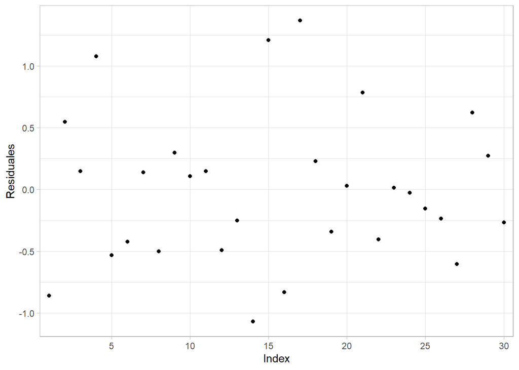

```r
ggplot(data.frame(Residuales=res.aov$residuals,Index=rownames(res.aov$model)),
       aes(y=Residuales,x=Index))+
       geom_point()+
       scale_x_discrete(limits=rownames(res.aov$model),
                        breaks=c("0","5","10","15","20","25","30"))+
       theme_light()
```

En este caso, parece no existir tendencia alguna.

## Normalidad

La variable cuantitativa debe de distribuirse de forma normal en cada uno de los grupos, siendo menos estricta esta condición cuanto mayor sea el tamaño de cada grupo. La mejor forma de verificar la normalidad es estudiar los residuos de cada observación respecto a la media del grupo al que pertenecen.

### Medidas descriptivas

```r
summary(res.aov$residuals)
```

```
##    Min. 1st Qu.  Median    Mean 3rd Qu.    Max.
## -1.0710 -0.4180 -0.0060  0.0000  0.2627  1.3690
```

A partir de las medidas de tendencia central y localización se puede pensar que los residuales son simétricos alrededor de la media. Lo cual, es un indicio clave en el análisis de normalidad.

### Análisis gráfico

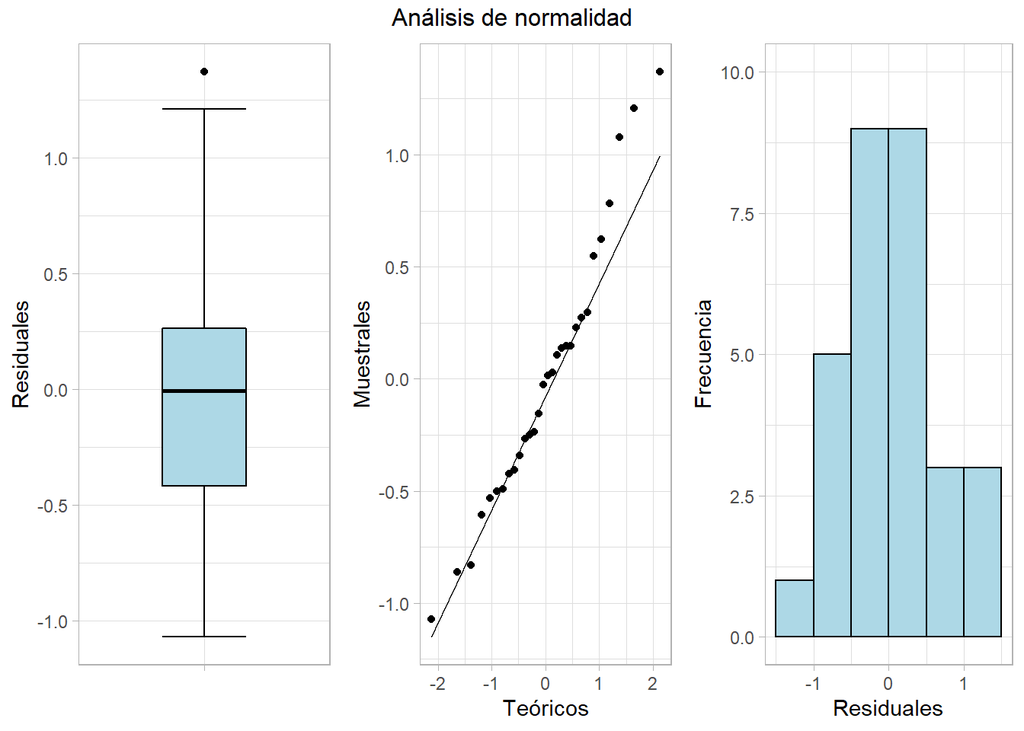

```r
#Diagrama de caja
p1<-ggplot(data.frame(Residuales=res.aov$residuals,dat),
       aes(x="",y=Residuales))+
       stat_boxplot(geom = 'errorbar',width=0.4)+
       geom_boxplot(colour="black",fill="lightblue",
                    varwidth = TRUE,width=0.4)+
      labs(x="",y="Residuales")+
       theme_light()

#Gráfico QQ
p2<-ggplot(data.frame(Residuales=res.aov$residuals),
       aes(sample=Residuales))+
       stat_qq()+
       stat_qq_line()+
       labs(x="Teóricos",y="Muestrales")+
       theme_light()

#Sturges
brx <- pretty(range(res.aov$residuals),
              n = nclass.Sturges(res.aov$residuals),min.n = 1)

#Histograma

#Sturges
brx <- pretty(range(res.aov$residuals),
              n = nclass.Sturges(res.aov$residuals),min.n = 1)

p3<-ggplot(data.frame(Residuales=res.aov$residuals),
       aes(x=Residuales))+
       geom_histogram(color="black",fill="lightblue", breaks=brx)+
       scale_x_continuous("Residuales") +
       ylim(0,10)+
       labs(x="Residuales",y="Frecuencia")+
       theme_light()

#Gráfico completo
grid.arrange(p1,p2,p3,nrow=1,top = "Análisis de normalidad")
```

El análisis gráfico es la segunda etapa para validar el supuesto de normalidad. El diagrama de caja presenta una leve asimetría positiva, es decir, la distribución se alarga a valores mayores que la media. Además, se presentan datos atípicos. Por otro lado, el gráfico cuantil cuantil (qq) alerta sobre la presencia de observaciones que parecen no seguir la distribución normal. Finalmente, el histograma muestra que los datos están muy concentrados alrededor de la media, lo cúal causa que la curva sea muy apuntada.

### Análisis estadístico

Existen múltiples test estadísticos para verificar el supuesto de normalidad, los dos más conocidos son los siguientes:

#### Test de Shapiro Wilk

El Test de Shapiro–Wilk se usa para contrastar la normalidad de un conjunto de datos. Se plantea como hipótesis nula que una muestra $x_1, ..., x_n$ proviene de una población normalmente distribuida.

```r
shapiro.test(res.aov$residuals)
```

```
##
##  Shapiro-Wilk normality test
##
## data:  res.aov$residuals
## W = 0.96607, p-value = 0.4379
```

El p-valor asociado a esta prueba es de 0.4379, mayor que el nivel de signifancia del 5%. Por lo cual, no existe suficiente evidencia para rechazar la hipótesis nula. Es decir, el supuesto de normalidad se cumple.

#### Test de Lilliefors

El test de Kolmogorov-Smirnov (con la corrección Lilliefors) se utiliza para contrastar si un conjunto de datos se ajustan o no a una distribución normal. Al igual que el test de Sahpiro, la hipótesis nula es los datos proceden de una distribución normal.

```r
lillie.test(res.aov$residuals)
```

```
##
##  Lilliefors (Kolmogorov-Smirnov) normality test
##
## data:  res.aov$residuals
## D = 0.11015, p-value = 0.4653
```

El p-valor asociado a esta prueba es de 0.4653, mayor que el nivel de signifancia del 5%. Por lo cual, no existe suficiente evidencia para rechazar la hipótesis nula. Es decir, el supuesto de normalidad se cumple.

## Homocedasticidad

Varianza constante entre grupos (homocedasticidad): La varianza dentro de los grupos debe de ser aproximadamente igual en todos ellos. Esto es así ya que en la hipótesis nula se considera que todas las observaciones proceden de la misma población, por lo que tienen la misma media y también la misma varianza.

### Análisis gráfico

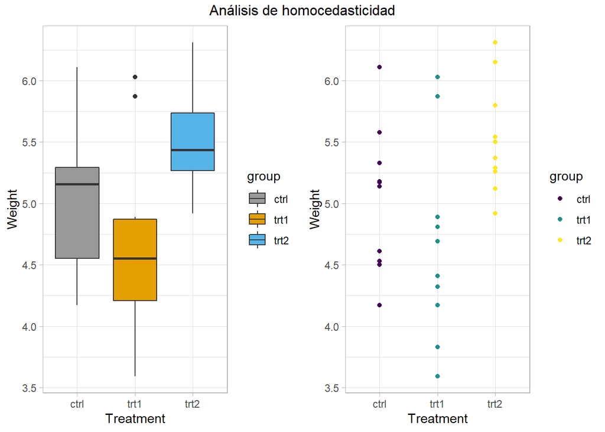

```r
#Diagramas de caja por grupo
p4<-ggplot(dat,aes(x=group,y=weight,fill=group))+
  geom_boxplot()+
  labs(y = "Weight", x = "Treatment")+
  scale_x_discrete(limits=c("ctrl", "trt1", "trt2"))+
  scale_fill_manual(values=c("#999999", "#E69F00", "#56B4E9"))+
  theme_light()#BASIC BOX PLOT

#Gráfico de puntos por grupo
p5<-ggplot(dat,aes(x=group,y=weight,colour=group))+
  geom_point()+
  labs(y = "Weight", x = "Treatment")+
  scale_x_discrete(limits=c("ctrl", "trt1", "trt2"))+
  scale_fill_manual(values=c("#999999", "#E69F00", "#56B4E9"))+
  theme_light()#BASIC BOX PLOT

#Gráfico conjunto
grid.arrange(p4,p5,nrow=1,top="Análisis de homocedasticidad")
```

Mediante estos gráficos se puede observar mayor dispersión para los datos de trt1. Además, parece haber una diferencia entre la dispersión de los grupos ctrl y trt2. Se puede observar, que en el grupo trt1 existen valores atípicos, los cuales pueden estar causando una inflación en la varianza.

### Análisis estadístico

A continuación se presentan los test estadísticos más reconocidos para la detección de problemas de heterocedasticidad.

#### Test de Bartlett

La prueba de Bartlett se utiliza para probar si k muestras provienen de poblaciones con la misma varianza. A las varianzas iguales a través de las muestras se llama homocedasticidad u homogeneidad de varianzas. La prueba de Bartlett es sensible a las desviaciones de la normalidad. En otras palabras, $H_0$ es que todas las varianzas de una población k son iguales, frente a la hipótesis alternativa de que al menos dos son diferentes.

```r
bartlett.test(weight ~ group, data=dat)
```

```
##
##  Bartlett test of homogeneity of variances
##
## data:  weight by group
## Bartlett's K-squared = 2.8786, df = 2, p-value = 0.2371
```

El p-valor asociada a esta prueba es de 0.2371, mayor que el nivel de significancia del 5%. Por lo cual, no existe suficiente evidencia estadística para rechazar la hipótesis nula. Es decir, se cumple el supuesto de homocedastícidad.

#### Test de Levene

La prueba de Levene es una prueba estadística inferencial utilizada para evaluar la igualdad de las varianzas para una variable calculada para dos o más grupos. Se pone a prueba la hipótesis nula de que las varianzas poblacionales son iguales (llamado homogeneidad de varianza ú homocedasticidad).

```r
leveneTest(weight ~ group, data=dat)
```

```
## Levene's Test for Homogeneity of Variance (center = median)
##       Df F value Pr(>F)
## group  2  1.1192 0.3412
##       27
```

El p-valor asociado a esta prueba es de 0.3412, mayor que el nivel de significancia del 5%. Por lo cual, no existe suficiente evidencia estadística para rechazar la hipótesis nula. Es decir, se llega a la misma conclusión que la obtenida con la prueba de Bartlett.

Tras realizar la validación de los supuestos del ANOVA, se concluye que esta tecnica estadística es válida para realizar análisis inferenciales sobre el conjunto de datos. Puesto que se rechaza la hipótesis nula del ANOVA, existen diferencias significativas entre al menos dos medias. El paso siguiente es determinar para que pareja de medias se presenta esta situación, para lo cual se deben aplicar métodos de comparación múltiple.

## Pruebas de comparación múltiple

### Test de Tukey

La prueba Tukey se usa en experimentos que implican un número elevado de comparaciones. Es de fácil cálculo puesto que se define un solo comparador, resultante del producto del error estándar de la media por el valor tabular en la tabla de Tukey usando como numerador el número de tratamientos y como denominador los grados de libertad del error.

- Dado que el análisis de varianza acuse un efecto significativo, la prueba de Tukey provee un nivel de significancia global de α cuando los tamaños de las muestras son iguales y de α a lo sumo a cuando no son iguales.
- Se basa en la construcción de intervalos de confianza de las diferencias por pares. Si estos intervalos incluyen al 0, entonces no se rechaza la hipótesis nula.

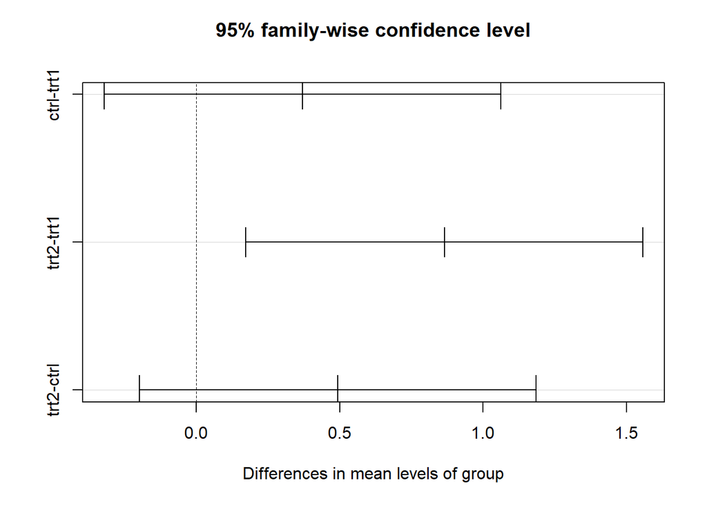

```r
Tukey=TukeyHSD(res.aov, "group", ordered = TRUE)
plot(Tukey)
```

```r
Tukey
```

```
##   Tukey multiple comparisons of means
##     95% family-wise confidence level
##     factor levels have been ordered
##
## Fit: aov(formula = weight ~ group, data = dat)
##
## $group
##            diff        lwr      upr     p adj
## ctrl-trt1 0.371 -0.3202161 1.062216 0.3908711
## trt2-trt1 0.865  0.1737839 1.556216 0.0120064
## trt2-ctrl 0.494 -0.1972161 1.185216 0.1979960
```

La prueba de Tukey indica que existen diferencias significativas entre el peso promedio tras aplicar el tratamiento 1 y el tratamiento 2.

### Diferencia mínima significativa (LSD)

Es el método de comparación múltiple posiblemente más utilizado, debido quizás a su fácil manera de aplicar. Es usualmente usado pra comparar una pareja de medias de tratamientos, pero puede ser utilizado para comparaciones de más de dos medias de tratamientos.

Esta prueba determina el valor mínimo necesario para considerar diferentes dos tratamientos y lo utiliza para comparar los diferentes pares de medias que se deseen evaluar. Los pares de medias que se comparan son los que han sido planeados antes de ejecutar el experimento, por ello es una prueba para comparaciones planeadas.

```r
L<-lsdTest(res.aov)
L
```

```
##
##  Pairwise comparisons using Least Significant Difference Test
```

```
## data: weight by group
```

```
##      ctrl   trt1
## trt1 0.1944 -
## trt2 0.0877 0.0045
```

```
##
## P value adjustment method: none
```

```
## alternative hypothesis: two.sided
```

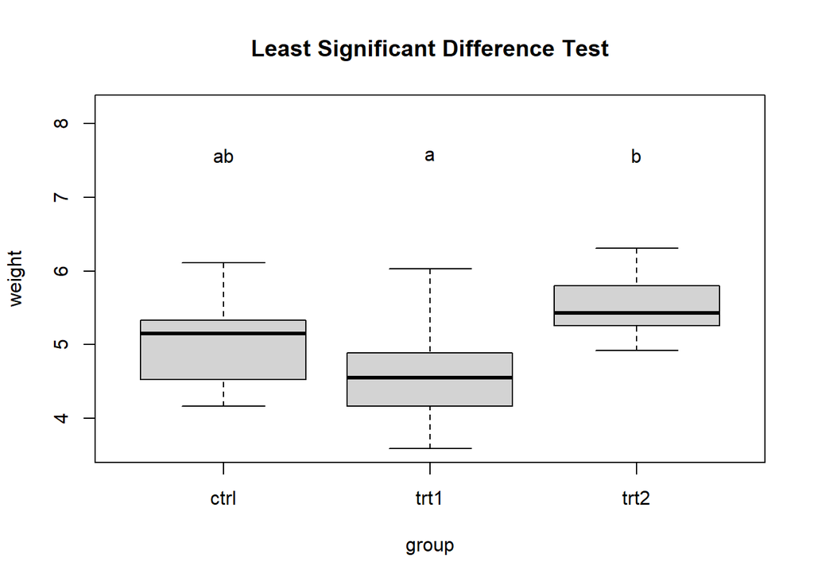

```r
plot(L)
```

La prueba LSD indica que existen diferencias significativas entre el peso promedio tras aplicar los tratamientos 1 y 2.

# Test de Kruskal Wallis

El test de Kruskal-Wallis, también conocido como test H, es la alternativa no paramétrica al test ANOVA de una vía para datos no pareados. Se trata de un test que emplea rangos para contrastar la hipótesis de que k muestras han sido obtenidas de una misma población.

A diferencia del ANOVA en el que se comparan medias, el test de Kruskal-Wallis contrasta si las diferentes muestras están equidistribuidas y que por lo tanto pertenecen a una misma distribución (población). Bajo ciertas simplificaciones puede considerarse que el test de Kruskal-Wallis compara las medianas.

$$\begin{align}
\begin{cases}
H_0: & \text{todas las muestras provienen de la misma población (distribución).} \\
H_a: & \text{Al menos una muestra proviene de una población con una distribución distinta.}
\end{cases}
\end{align}$$

El test de Kruskal-Wallis es el test adecuado cuando los datos tienen un orden natural, es decir, cuando para darles sentido tienen que estar ordenados o bien cuando no se satisfacen las condiciones para poder aplicar un ANOVA.

Supóngase que se dispone de k grupos cada uno con n observaciones. Si se ordenan todas las observaciones de menor a mayor y se le asigna a cada una de ellas su rango, cuando se obtenga la suma de rangos para cada uno de los grupos (Ri) es de esperar que, si se cumple la hipótesis nula, todos los grupos tengan un valor similar. Partiendo de esta idea se calcula el estadístico H como:

$$\begin{align}
H = \frac{12}{N(N+1)}\sum_{i=1}^k \frac{R^2_i}{n_i} - 3(N+1)
\end{align}$$
Este test presenta las siguientes condiciones:

-No es necesario que las muestras que se comparan provengan de una distribución normal.

-Homocedasticidad: dado que la hipótesis nula asume que todos los grupos pertenecen a una misma población y que por lo tanto tienen las mismas medianas, es requisito necesario que todos los grupos tengan la misma varianza.

Se trabajará con los mismos datos usados para el ANOVA. Como ya se probo anteriormente, el supuesto de homocedasticidad se cumple. Por lo cual, se aplica el test de Kruskal-Wallis y se obtiene:

```r
kruskal.test(weight ~ group, data = dat)
```

```
##
##  Kruskal-Wallis rank sum test
##
## data:  weight by group
## Kruskal-Wallis chi-squared = 7.9882, df = 2, p-value = 0.01842
```

El p-valor asociado a esta prueba es de 0.01842, menor que el nivel de signifcancia del 5%. Por lo tanto, existe suficiente evidencia estadística para rechazar la hipótesis nula. Es decir, los datos no provienen de la misma población.

La conclusión obtenida tras realizar el test de Kruskal-Wallis es equivalente al resultado del ANOVA.

## Pruebas de comparación múltiple

### Test de comparación múltiple

El test de Bonferroni-Dunn es una prueba no paramétrica de comparación múltiple.

```r
dunn.test(dat$weight, g=dat$group, method="bonferroni", kw=TRUE, label=TRUE, alpha=0.05)
```

```
##   Kruskal-Wallis rank sum test
##
## data: x and group
## Kruskal-Wallis chi-squared = 7.9882, df = 2, p-value = 0.02
##
##
##                            Comparison of x by group
##                                  (Bonferroni)
## Col Mean-|
## Row Mean |       ctrl       trt1
## ---------+----------------------
##     trt1 |   1.117725
##          |     0.3955
##     trt2 |  -1.689289  -2.807015
##          |     0.1367    0.0075*
##
## alpha = 0.05
## Reject Ho if p <= alpha/2
```

Indica que existen diferencias significativas en el peso promedio luego de aplicar el tratamiento 1 y el tratamiento 2.